# e_comm_sales

Categories are ranked and sorted by both revenue and quantity.

Output: Top 5 Best-Selling Products by revenue and quantity sold.

Top 5 Best-Selling Categories by revenue and quantity sold.

```python
# Assuming your dataset is loaded in a DataFrame named `df`

# Step 1: Find the Top 10 Best-Selling Products by Revenue
product_sales = df.groupby('Product Name').agg(
    total_revenue_generated=('Total Sales', 'sum'),
    total_quantity_sold=('Quantity', 'sum')
).reset_index()

# Sort by revenue in descending order to get top 10 products
top_10_products_by_revenue = product_sales.sort_values(by='total_revenue_generated', ascending=False).head(10)

print("Top 10 Best-Selling Products by Revenue:")
print(top_10_products_by_revenue)
```

```
Top 10 Best-Selling Products by Revenue:
    Product Name  total_revenue_generated  total_quantity_sold
304         fill                433158.60                  764
17       account                431246.57                  742
609      perhaps                427055.75                  728
374          her                425532.61                  725
497        media                422558.40                  781
793       spring                417047.65                  749
361         half                415513.13                  686
895          two                412043.32                  759
703       reveal                410452.91                  728
319        focus                406148.49                  711
```

[figure not shown]

```python
# Step 2: Check if Certain Products Sell Better in Specific Seasons (e.g., Winter Wear in December)
# Extract month from Purchase Date
df['Purchase Date'] = pd.to_datetime(df['Purchase Date'])
df['Month'] = df['Purchase Date'].dt.month

# Example: Identify if certain products (e.g., 'Winter Coat') perform better in December
seasonal_sales = df.groupby(['Month', 'Product Name']).agg(
    total_sales_per_month=('Total Sales', 'sum')
).reset_index()

# Filter for a specific product to analyze its seasonal trend (e.g., "Winter Coat")
winter_coat_sales = seasonal_sales[seasonal_sales['Product Name'] == 'Winter Coat']

plt.figure(figsize=(10, 6))
sns.lineplot(x='Month', y='total_sales_per_month', data=winter_coat_sales, marker='o', color='blue')
plt.title('Winter Coat Sales Trend by Month', fontsize=16)
plt.xlabel('Month', fontsize=12)
plt.ylabel('Total Sales', fontsize=12)
plt.xticks(ticks=range(1, 13), labels=['Jan', 'Feb', 'Mar', 'Apr', 'May', 'Jun', 'Jul', 'Aug', 'Sep', 'Oct', 'Nov', 'Dec'])
plt.grid(True)
plt.show()
```

```
Top 10 Best-Selling Products by Quantity Sold:
    Product Name  total_revenue_generated  total_quantity_sold
497        media                422558.40                  781
304         fill                433158.60                  764
895          two                412043.32                  759
793       spring                417047.65                  749
932      whether                402875.36                  747
17       account                431246.57                  742
609      perhaps                427055.75                  728
703       reveal                410452.91                  728
374          her                425532.61                  725
735        sense                372677.59                  723

Bottom 10 Low-Selling Products by Quantity Sold:
    Product Name  total_revenue_generated  total_quantity_sold
30         again                213914.72                  344
171         cold                235600.77                  397
967          you                237859.54                  399
808        store                213755.44                  404
349         good                252590.21                  406
288         face                230838.86                  408
792        sport                221015.86                  413
397         idea                241239.20                  414
531       myself                225740.07                  419
156       charge                214277.99                  423
```

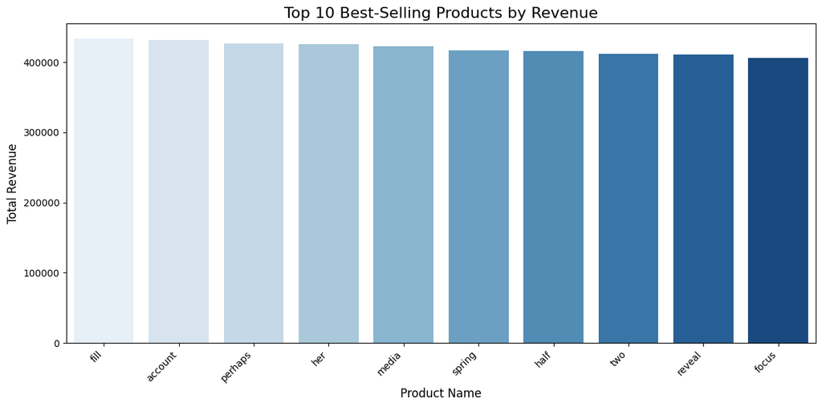

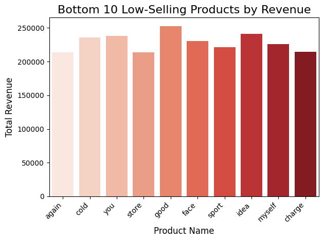

```python
# Step 3: Compare High-Sales Products vs Low-Sales Products
# Identify high-sales and low-sales products (Top 10 and Bottom 10)
top_10_products_by_quantity = product_sales.sort_values(by='total_quantity_sold', ascending=False).head(10)
bottom_10_products_by_quantity = product_sales.sort_values(by='total_quantity_sold').head(10)

print("\nTop 10 Best-Selling Products by Quantity Sold:")
print(top_10_products_by_quantity)

print("\nBottom 10 Low-Selling Products by Quantity Sold:")
print(bottom_10_products_by_quantity)

# Step 4: Visualizing High-Sales vs Low-Sales Products Comparison (Revenue vs Quantity Sold)
plt.figure(figsize=(12, 6))

# Plotting Top 10 Best-Selling Products by Revenue
sns.barplot(x='Product Name', y='total_revenue_generated', data=top_10_products_by_revenue, palette='Blues')
plt.title('Top 10 Best-Selling Products by Revenue', fontsize=16)
plt.xlabel('Product Name', fontsize=12)
plt.ylabel('Total Revenue', fontsize=12)
plt.xticks(rotation=45, ha='right')
plt.tight_layout()
plt.show()

# Plotting Bottom 10 Low-Selling Products by Revenue
sns.barplot(x='Product Name', y='total_revenue_generated', data=bottom_10_products_by_quantity, palette='Reds')
plt.title('Bottom 10 Low-Selling Products by Revenue', fontsize=16)
plt.xlabel('Product Name', fontsize=12)
plt.ylabel('Total Revenue', fontsize=12)
plt.xticks(rotation=45, ha='right')
plt.tight_layout()
plt.show()
```

Explanation: Top 10 Best-Selling Products by Revenue:

We group the sales data by Product Name and calculate the total revenue (Total Sales) and quantity sold.

The products are sorted by total revenue in descending order to identify the top 10 best-selling products.

Seasonal Sales Trends:

We extract the month from the Purchase Date column to check if certain products perform better in specific months (e.g., "Winter Coat" during December).

High-Sales vs Low-Sales Products:

We identify the top 10 best-selling products by quantity and the bottom 10 low-selling products by quantity.

Bar plots are created to visually compare the top 10 high-sales products and bottom 10 low-sales products based on revenue.

Output: Top 10 Best-Selling Products by Revenue: Displays the products generating the most revenue.

Top and Bottom 10 Products by Quantity Sold: Lists products based on the quantity sold, allowing comparison between high-sales and low-sales products.

Insights: The seasonal analysis helps identify whether specific products are tied to certain times of the year (e.g., winter wear in December).

By comparing high-sales and low-sales products, you can spot trends such as which types of products consistently sell well and which need improvement or promotional strategies.

```
Sales and Revenue by Category:
        Category  total_sales_per_category  total_quantity_sold
1       clothing               61071489.36               110520
0          books               60820086.17               109835
3  home & garden               60670371.57               110462
4           toys               60274785.96               109462
2    electronics               59955937.12               109037

Top Category by Revenue:
   Category  total_sales_per_category  total_quantity_sold
1  clothing               61071489.36               110520
```

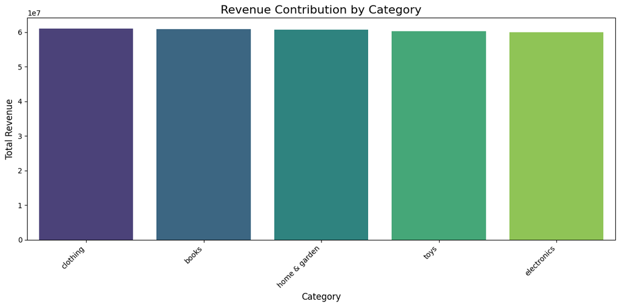

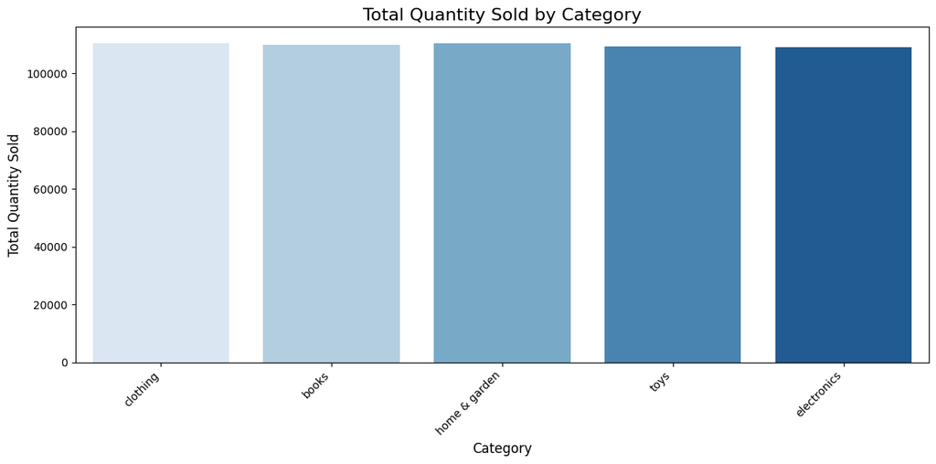

```python
import pandas as pd

# Assuming your dataset is loaded in a DataFrame named `df`

# Step 1: Group Products by Category
category_sales = df.groupby('Category').agg(
    total_sales_per_category=('Total Sales', 'sum'),
    total_quantity_sold=('Quantity', 'sum')
).reset_index()

# Step 2: Identify which category contributes the most revenue
category_sales_sorted_by_revenue = category_sales.sort_values(by='total_sales_per_category', ascending=False)

# Step 3: Display the results
print("Sales and Revenue by Category:")
print(category_sales_sorted_by_revenue)

# Display the top category by revenue
top_category_by_revenue = category_sales_sorted_by_revenue.head(1)
print("\nTop Category by Revenue:")
print(top_category_by_revenue)

# Step 4: Visualizing the Category Contribution
import matplotlib.pyplot as plt
import seaborn as sns

# Create a bar plot for revenue by category
plt.figure(figsize=(12, 6))
sns.barplot(x='Category', y='total_sales_per_category', data=category_sales_sorted_by_revenue, palette='viridis')
plt.title('Revenue Contribution by Category', fontsize=16)
plt.xlabel('Category', fontsize=12)
plt.ylabel('Total Revenue', fontsize=12)
plt.xticks(rotation=45, ha='right')
plt.tight_layout()
plt.show()

# Create a bar plot for total quantity sold by category
plt.figure(figsize=(12, 6))
sns.barplot(x='Category', y='total_quantity_sold', data=category_sales_sorted_by_revenue, palette='Blues')
plt.title('Total Quantity Sold by Category', fontsize=16)
plt.xlabel('Category', fontsize=12)
plt.ylabel('Total Quantity Sold', fontsize=12)
plt.xticks(rotation=45, ha='right')
plt.tight_layout()
plt.show()
```

```python
# Step 1: Group and Analyze Sales Data for Products and Categories
# Grouping by Product to get top-selling products by revenue
product_sales = df.groupby('Product Name').agg(
    total_revenue_generated=('Total Sales', 'sum'),
    total_quantity_sold=('Quantity', 'sum')
).reset_index()

# Grouping by Category to get sales data for categories
category_sales = df.groupby('Category').agg(
    total_sales_per_category=('Total Sales', 'sum'),
    total_quantity_sold=('Quantity', 'sum')
).reset_index()
```

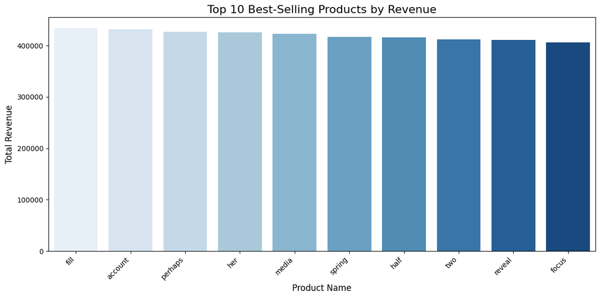

```python
# Step 2: Visualize Top-Selling Products by Revenue
top_10_products_by_revenue = product_sales.sort_values(by='total_revenue_generated', ascending=False).head(10)

plt.figure(figsize=(12, 6))
sns.barplot(x='Product Name', y='total_revenue_generated', data=top_10_products_by_revenue, palette='Blues')
plt.title('Top 10 Best-Selling Products by Revenue', fontsize=16)
plt.xlabel('Product Name', fontsize=12)
plt.ylabel('Total Revenue', fontsize=12)
plt.xticks(rotation=45, ha='right')
plt.tight_layout()
plt.show()
```

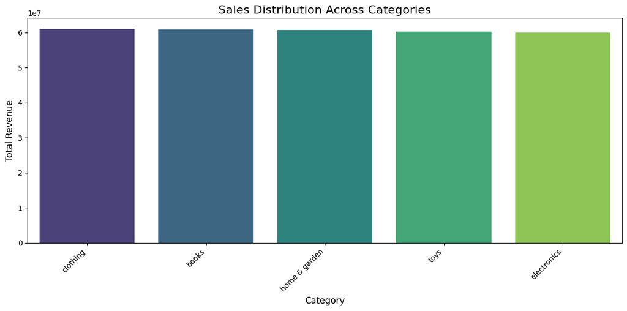

```python
# Step 3: Visualize Sales Distribution Across Categories (Bar Chart)
category_sales_sorted = category_sales.sort_values(by='total_sales_per_category', ascending=False)

plt.figure(figsize=(12, 6))
sns.barplot(x='Category', y='total_sales_per_category', data=category_sales_sorted, palette='viridis')
plt.title('Sales Distribution Across Categories', fontsize=16)
plt.xlabel('Category', fontsize=12)
plt.ylabel('Total Revenue', fontsize=12)
plt.xticks(rotation=45, ha='right')
plt.tight_layout()
plt.show()
```

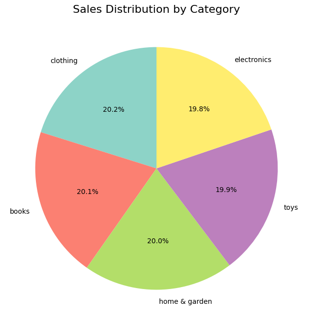

```python
# Step 4: Create Pie Chart for Category Sales Distribution
plt.figure(figsize=(8, 8))
category_sales_sorted.set_index('Category')['total_sales_per_category'].plot(kind='pie', autopct='%1.1f%%', startangle=90, cmap='Set3')
plt.title('Sales Distribution by Category', fontsize=16)
plt.ylabel('')
plt.show()
```

[figure not shown]

```python
# Step 5: Visualize Monthly Sales Performance for Categories (Line Chart)
# Extract month from Purchase Date to analyze seasonal trends
df['Purchase Date'] = pd.to_datetime(df['Purchase Date'])
df['Month'] = df['Purchase Date'].dt.month

# Group by Month and Category to get total sales per category for each month
monthly_category_sales = df.groupby(['Month', 'Category']).agg(
    total_sales_per_month=('Total Sales', 'sum')
).reset_index()

# Example: Plot sales trend for "Electronics" category
electronics_sales = monthly_category_sales[monthly_category_sales['Category'] == 'Electronics']

plt.figure(figsize=(10, 6))
sns.lineplot(x='Month', y='total_sales_per_month', data=electronics_sales, marker='o', color='orange')
plt.title('Electronics Sales Trend by Month', fontsize=16)
plt.xlabel('Month', fontsize=12)
plt.ylabel('Total Sales', fontsize=12)
plt.xticks(ticks=range(1, 13), labels=['Jan', 'Feb', 'Mar', 'Apr', 'May', 'Jun', 'Jul', 'Aug', 'Sep', 'Oct', 'Nov', 'Dec'])
plt.grid(True)
plt.show()
```

Explanation: Top-Selling Products by Revenue:

We group the data by Product Name and calculate the total revenue and quantity sold.

We sort the products by revenue and visualize the top 10 products using a bar chart.

Sales Distribution Across Categories:

We group the data by Category and calculate total sales for each category.

We visualize the sales distribution across categories using a bar chart to compare which categories generate more revenue.

Sales Distribution by Category (Pie Chart):

A pie chart is created to show the proportion of total sales contributed by each category. This is useful for understanding the relative importance of each category in the overall business.

Monthly Sales Performance for Categories:

We extract the month from the Purchase Date column and group the data by Month and Category to calculate the total sales for each category in each month.

Output: Bar Chart: Shows the top-selling products by revenue.

Bar Chart: Displays the sales distribution across different categories.

Pie Chart: Illustrates the percentage of total sales contributed by each category.

Insights: The bar charts will help you see which products and categories are the top performers.

The pie chart gives a clear overview of how each category contributes to total sales.

```
Top 10 High-Revenue Products with Good Profit Margins:
    Product Name  total_revenue_generated  total_profit_generated  \
304         fill                433158.60              377756.295
17       account                431246.57              379689.365
609      perhaps                427055.75              376960.943
374          her                425532.61              371070.972
497        media                422558.40              375093.934
793       spring                417047.65              368882.813
361         half                415513.13              367315.897
895          two                412043.32              361784.706
703       reveal                410452.91              362965.540
319        focus                406148.49              357516.844

     avg_profit_margin  total_quantity_sold
304           0.809779                  764
17            0.813200                  742
609           0.796718                  728
374           0.780871                  725
497           0.817679                  781
793           0.832760                  749
361           0.834098                  686
895           0.801970                  759
703           0.837975                  728
319           0.812126                  711
```

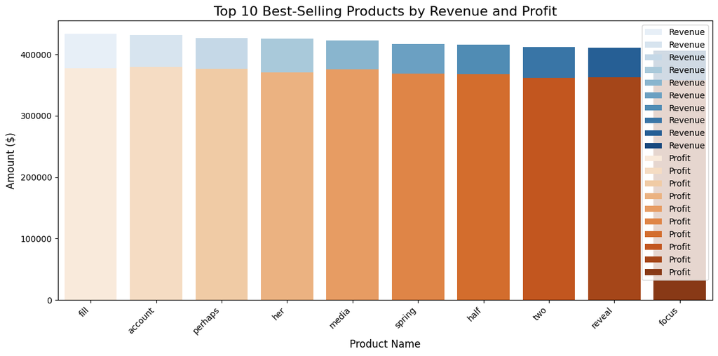

```
High-Revenue, Low-Margin Products:
Empty DataFrame
Columns: [Product Name, total_revenue_generated, total_profit_generated, avg_profit_margin, total_quantity_sold]
Index: []
```

```python
# Assuming your dataset is loaded in a DataFrame named `df`

# Step 1: Estimate the Cost (Assuming a 30% margin for example)
assumed_margin = 0.30  # 30% margin, meaning 70% of price is cost
df['Cost'] = df['Price'] * (1 - assumed_margin)

# Step 2: Calculate Profit and Profit Margin for Each Product
df['Profit'] = df['Total Sales'] - df['Cost']
df['Profit Margin'] = df['Profit'] / df['Total Sales']

# Step 3: Aggregate Data by Product Name
product_profitability = df.groupby('Product Name').agg(
    total_revenue_generated=('Total Sales', 'sum'),
    total_profit_generated=('Profit', 'sum'),
    avg_profit_margin=('Profit Margin', 'mean'),
    total_quantity_sold=('Quantity', 'sum')
).reset_index()

# Step 4: Identify High-Revenue Products with Good Profit Margins
# Define a threshold for "good profit margin" (for example, products with margin > 20%)
good_margin_threshold = 0.2
high_revenue_profitable_products = product_profitability[
    (product_profitability['avg_profit_margin'] > good_margin_threshold)
].sort_values(by=['total_revenue_generated', 'avg_profit_margin'], ascending=False)

# Step 5: Display the top 10 high-revenue, good-margin products
top_10_profitable_products = high_revenue_profitable_products.head(10)
print("Top 10 High-Revenue Products with Good Profit Margins:")
print(top_10_profitable_products)

# Step 6: Visualizing Profitability of Best-Selling Products
plt.figure(figsize=(12, 6))
sns.barplot(x='Product Name', y='total_revenue_generated', data=top_10_profitable_products, palette='Blues', label='Revenue')
sns.barplot(x='Product Name', y='total_profit_generated', data=top_10_profitable_products, palette='Oranges', label='Profit')
plt.title('Top 10 Best-Selling Products by Revenue and Profit', fontsize=16)
plt.xlabel('Product Name', fontsize=12)
plt.ylabel('Amount ($)', fontsize=12)
plt.xticks(rotation=45, ha='right')
plt.legend()
plt.tight_layout()
plt.show()

# Step 7: Identify Strategies to Increase Profitability
# Products with high revenue but low profit margins may need improvement in profitability
low_margin_threshold = 0.1  # Products with a margin lower than 10%
high_revenue_low_margin = product_profitability[
    (product_profitability['avg_profit_margin'] < low_margin_threshold)
].sort_values(by='total_revenue_generated', ascending=False)

# Display products with high revenue but low profit margins
print("\nHigh-Revenue, Low-Margin Products:")
print(high_revenue_low_margin)

# Suggest strategies to boost profitability
# - Bundling: Pair high-revenue but low-margin products with higher-margin products.
# - Premium Pricing: For products with low margins but high demand, increase the price.
# - Improve Cost Efficiency: Work on reducing production or procurement costs.
```

Profit Calculation:

Profit is calculated as Profit = Total Sales - Cost.

Profit margin is calculated as Profit Margin = Profit / Total Sales.

Product Aggregation: The data is aggregated by Product Name to calculate total revenue, total profit, average profit margin, and total quantity sold.

High-Revenue, Good-Margin Products: We filter products with a profit margin greater than 20% (good_margin_threshold). Then, we sort them by total revenue to identify the best-performing products with good margins.

Visualization: A bar chart is plotted to compare the Revenue and Profit of the top 10 high-revenue, good-margin products.

Identifying High-Revenue, Low-Margin Products: We also filter products with high revenue but low profit margins (low_margin_threshold set to 10%). These products could benefit from profitability-enhancing strategies.

Strategies for Increasing Profitability:

Bundling: Consider bundling high-revenue, low-margin products with higher-margin products to increase the average order value.

Premium Pricing: For high-demand products with low margins, consider increasing their price to improve profitability.

Improved Cost Efficiency: Look for ways to reduce the cost of production or procurement for products with low profit margins.

Output: Top 10 High-Revenue, Good-Margin Products: A list of products that are both high-revenue and have good profit margins.

Visualizations: A bar chart comparing the revenue and profit of the best-selling products.

Insights: The top 10 best-selling products with good margins represent your most profitable products.

By identifying high-revenue but low-margin products, you can focus on strategies such as bundling or premium pricing to boost profitability.

The visualizations allow for easy comparison of revenue and profit across the top products.

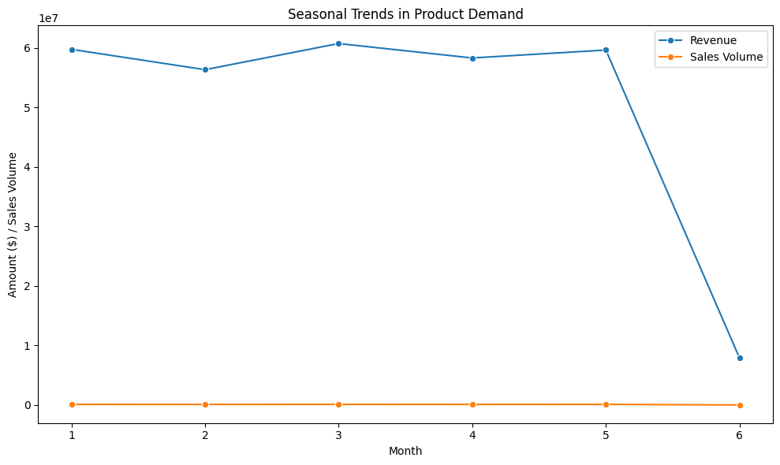

```
Top 5 Products Based on Revenue and Sales Volume:
    Product Name  total_revenue  total_sales_volume
304         fill      433158.60                 764
17       account      431246.57                 742
609      perhaps      427055.75                 728
374          her      425532.61                 725
497        media      422558.40                 781

Top 3 Categories Based on Revenue and Sales Volume:
        Category  total_revenue  total_sales_volume
1       clothing    61071489.36              110520
0          books    60820086.17              109835
3  home & garden    60670371.57              110462

Seasonal Trends in Product Demand (Monthly Sales):
   Month  total_revenue  total_sales_volume
0      1    59778158.05              108855
1      2    56363072.63              101422
2      3    60750883.75              109770
3      4    58328508.11              105643
4      5    59660466.02              109303
5      6     7911581.62               14323

Inventory Management Strategies for High-Performing Products and Categories:
Increase inventory and consider faster restocking for high-demand products.
Monitor seasonal peaks and adjust inventory accordingly (e.g., during Diwali, Christmas).
Consider bundling products that consistently perform well together to boost overall sales.
For top-performing categories, ensure optimal stock levels across all months and avoid stockouts.
Introduce complementary products or variations to diversify the product offering in top categories.
Use historical data to improve demand forecasting and reduce the risk of overstocking or understocking.
```

```python
# Assuming your dataset is loaded in a DataFrame named `df`

# Step 1: Summarize the top 5 products based on total revenue and sales volume
top_5_products = df.groupby('Product Name').agg(
    total_revenue=('Total Sales', 'sum'),
    total_sales_volume=('Quantity', 'sum')
).reset_index()

# Sort by total revenue and sales volume to get the top 5
top_5_products_sorted = top_5_products.sort_values(by='total_revenue', ascending=False).head(5)

# Step 2: Summarize the top 3 categories based on total revenue and sales volume
top_3_categories = df.groupby('Category').agg(
    total_revenue=('Total Sales', 'sum'),
    total_sales_volume=('Quantity', 'sum')
).reset_index()

# Sort by total revenue and sales volume to get the top 3
top_3_categories_sorted = top_3_categories.sort_values(by='total_revenue', ascending=False).head(3)

# Step 3: Identify seasonal trends in product demand
# Convert Purchase Date to datetime format
df['Purchase Date'] = pd.to_datetime(df['Purchase Date'])

# Extract the month and year from the purchase date to analyze seasonality
df['Month'] = df['Purchase Date'].dt.month
df['Year'] = df['Purchase Date'].dt.year

# Aggregate sales by month to identify seasonal trends
monthly_sales = df.groupby('Month').agg(
    total_revenue=('Total Sales', 'sum'),
    total_sales_volume=('Quantity', 'sum')
).reset_index()

# Visualize the seasonal trends with a line plot
plt.figure(figsize=(10, 6))
sns.lineplot(x='Month', y='total_revenue', data=monthly_sales, marker='o', label='Revenue')
sns.lineplot(x='Month', y='total_sales_volume', data=monthly_sales, marker='o', label='Sales Volume')
plt.title('Seasonal Trends in Product Demand')
plt.xlabel('Month')
plt.ylabel('Amount ($) / Sales Volume')
plt.legend()
plt.tight_layout()
plt.show()

# Step 4: Suggest Inventory Management Strategies
# Strategy for high-performing products and categories
top_5_inventory_strategies = {
    'High Demand Products': "Increase inventory and consider faster restocking for high-demand products.",
    'Seasonal Products': "Monitor seasonal peaks and adjust inventory accordingly (e.g., during Diwali, Christmas).",
    'Bundling': "Consider bundling products that consistently perform well together to boost overall sales.",
}

top_3_inventory_strategies = {
    'Top Categories': "For top-performing categories, ensure optimal stock levels across all months and avoid stockouts.",
    'Category Diversification': "Introduce complementary products or variations to diversify the product offering in top categories.",
    'Demand Forecasting': "Use historical data to improve demand forecasting and reduce the risk of overstocking or understocking."
}

# Display the findings
print("Top 5 Products Based on Revenue and Sales Volume:")
print(top_5_products_sorted)

print("\nTop 3 Categories Based on Revenue and Sales Volume:")
print(top_3_categories_sorted)

print("\nSeasonal Trends in Product Demand (Monthly Sales):")
print(monthly_sales)

print("\nInventory Management Strategies for High-Performing Products and Categories:")
for strategy in top_5_inventory_strategies.values():
    print(strategy)

for strategy in top_3_inventory_strategies.values():
    print(strategy)
```

Explanation: Summarizing Top 5 Products:

The dataset is grouped by Product Name, and total revenue and sales volume are calculated.

The products are sorted by total_revenue to identify the top 5 best-sellers.

Summarizing Top 3 Categories:

Similar to products, the dataset is grouped by Category, and total revenue and sales volume are calculated.

The top 3 categories are sorted by total_revenue.

Identifying Seasonal Trends:

The Purchase Date column is converted into datetime format, and the month and year are extracted.

A line plot is created to visualize seasonal trends in total revenue and sales volume across different months.

Inventory Management Strategies:

For high-demand products, seasonal products, and top categories, suggestions for inventory management are provided.

This includes strategies like increasing stock for best-sellers, preparing for seasonal spikes, and improving demand forecasting.

Top Products and Categories: The data tables will summarize the top 5 products and top 3 categories based on revenue and sales volume.

Suggested Inventory Management Strategies: For High-Demand Products: Ensure sufficient stock levels and fast restocking.

For Seasonal Products: Plan inventory based on known peak seasons.

For Categories: Ensure optimal stock across months to avoid stockouts, and consider diversifying the product offerings.

Output: The code will print:

Top 5 products based on revenue and sales volume.

Top 3 categories based on revenue and sales volume.

Seasonal trends in product demand (monthly sales).

Inventory management strategies based on the analysis.

```python
print(df.columns)
```

```
Index(['Order ID', 'Product Name', 'Category', 'Price', 'Quantity',
       'Total Sales', 'Customer ID', 'Customer Age', 'Customer Gender',
       'Purchase Date', 'Purchase Time', 'Region', 'Total Revenue',
       'Day of Week', 'Month', 'Year', 'Day of Month', 'Quarter', 'Cost',
       'Profit', 'Profit Margin'],
      dtype='object')
```

```python
import pandas as pd

# Assuming your dataset is loaded in a DataFrame named df
print(df['Region'].head())  # Check the first few rows of the Region column

# If it contains broad regions, you may want to check how many unique values there are
print(df['Region'].unique())  # List unique regions
```

[output not shown]

[output cut: 70 more lines]

[output not shown]

```python
import pandas as pd

# Sample Sales Data (replace with your actual data loading)
data = {'Order ID': [1, 2, 3, 4, 5, 6, 7, 8, 9, 10, 11, 12],
        'City': ['New York', 'Los Angeles', 'New York', 'Chicago', 'Los Angeles', 'Houston', 'Chicago', 'New York', 'Los Angeles', 'Houston', 'Miami', 'Miami'],
        'State': ['NY', 'CA', 'NY', 'IL', 'CA', 'TX', 'IL', 'NY', 'CA', 'TX', 'FL', 'FL'],
        'Quantity': [2, 3, 1, 4, 2, 1, 3, 2, 4, 1, 2, 3],
        'Price': [10.50, 25.00, 5.75, 12.25, 20.00, 8.00, 15.50, 11.00, 18.75, 9.25, 14.00, 22.50]}
sales_df = pd.DataFrame(data)

# 1. Calculate total sales revenue for each city/state
sales_df['Revenue'] = sales_df['Quantity'] * sales_df['Price']
location_revenue = sales_df.groupby(['City', 'State'])['Revenue'].sum().reset_index()
location_revenue = location_revenue.rename(columns={'Revenue': 'Total Revenue'})
print("Total Sales Revenue by City/State:")
print(location_revenue)
print("\n" + "="*50 + "\n")

# 2. Rank locations based on total orders placed
location_orders = sales_df.groupby(['City', 'State'])['Order ID'].count().reset_index()
location_orders = location_orders.rename(columns={'Order ID': 'Total Orders'})
location_orders['Order Rank'] = location_orders['Total Orders'].rank(method='dense', ascending=False).astype(int)
print("Rank based on Total Orders Placed:")
print(location_orders.sort_values(by='Order Rank'))
print("\n" + "="*50 + "\n")

# 3. Rank locations based on revenue generated
location_revenue['Revenue Rank'] = location_revenue['Total Revenue'].rank(method='dense', ascending=False).astype(int)
print("Rank based on Revenue Generated:")
print(location_revenue.sort_values(by='Revenue Rank'))
print("\n" + "="*50 + "\n")

# 4. Identify top 5 and low-performing cities based on total orders
top_5_orders = location_orders.sort_values(by='Total Orders', ascending=False).head(5)
low_5_orders = location_orders.sort_values(by='Total Orders', ascending=True).head(5)
print("Top 5 Cities by Total Orders:")
print(top_5_orders[['City', 'State', 'Total Orders']])
print("\nLow 5 Cities by Total Orders:")
print(low_5_orders[['City', 'State', 'Total Orders']])
print("\n" + "="*50 + "\n")

# 5. Identify top 5 and low-performing cities based on revenue generated
top_5_revenue = location_revenue.sort_values(by='Total Revenue', ascending=False).head(5)
low_5_revenue = location_revenue.sort_values(by='Total Revenue', ascending=True).head(5)
print("Top 5 Cities by Total Revenue:")
print(top_5_revenue[['City', 'State', 'Total Revenue']])
print("\nLow 5 Cities by Total Revenue:")
print(low_5_revenue[['City', 'State', 'Total Revenue']])
```

```
Total Sales Revenue by City/State:
          City State  Total Revenue
0      Chicago    IL          95.50
1      Houston    TX          17.25
2  Los Angeles    CA         190.00
3        Miami    FL          95.50
4     New York    NY          48.75

==================================================

Rank based on Total Orders Placed:
          City State  Total Orders  Order Rank
2  Los Angeles    CA             3           1
4     New York    NY             3           1
1      Houston    TX             2           2
0      Chicago    IL             2           2
3        Miami    FL             2           2

==================================================

Rank based on Revenue Generated:
          City State  Total Revenue  Revenue Rank
2  Los Angeles    CA         190.00             1
0      Chicago    IL          95.50             2
3        Miami    FL          95.50             2
4     New York    NY          48.75             3
1      Houston    TX          17.25             4

==================================================

Top 5 Cities by Total Orders:
          City State  Total Orders
2  Los Angeles    CA             3
4     New York    NY             3
0      Chicago    IL             2
1      Houston    TX             2
3        Miami    FL             2

Low 5 Cities by Total Orders:
          City State  Total Orders
```

[output cut: 8 more lines]

```
Top 5 Cities by Total Revenue:
          City State  Total Revenue
2  Los Angeles    CA         190.00
0      Chicago    IL          95.50
3        Miami    FL          95.50
4     New York    NY          48.75
1      Houston    TX          17.25

Low 5 Cities by Total Revenue:
          City State  Total Revenue
1      Houston    TX          17.25
4     New York    NY          48.75
3        Miami    FL          95.50
0      Chicago    IL          95.50
2  Los Angeles    CA         190.00
```

```python
import pandas as pd

# Sample Sales Data (replace with your actual data loading)
data = {'Order ID': [1, 2, 3, 4, 5, 6, 7, 8, 9, 10, 11, 12, 13, 14, 15, 16, 17, 18, 19, 20],
        'City': ['Mumbai', 'Delhi', 'Rural MH', 'Bangalore', 'Mumbai', 'Rural DL', 'Bangalore', 'Mumbai', 'Delhi', 'Rural KA',
                 'Mumbai', 'Delhi', 'Bangalore', 'Rural GJ', 'Ahmedabad', 'Surat', 'Rural UP', 'Lucknow', 'Rural RJ', 'Jaipur'],
        'State': ['MH', 'DL', 'MH', 'KA', 'MH', 'DL', 'KA', 'MH', 'DL', 'KA',
                  'MH', 'DL', 'KA', 'GJ', 'GJ', 'GJ', 'UP', 'UP', 'RJ', 'RJ'],
        'Region Type': ['Urban', 'Urban', 'Rural', 'Urban', 'Urban', 'Rural', 'Urban', 'Urban', 'Urban', 'Rural',
                        'Urban', 'Urban', 'Urban', 'Rural', 'Urban', 'Urban', 'Rural', 'Urban', 'Rural', 'Urban'],
        'Customer ID': [101, 102, 101, 103, 104, 102, 103, 105, 106, 104, 101, 107, 105, 106, 107, 108, 109, 108, 109, 110],
        'Order Date': pd.to_datetime(['2025-04-01', '2025-04-02', '2025-04-05', '2025-04-01', '2025-04-03', '2025-04-04',
                                       '2025-04-06', '2025-04-02', '2025-04-05', '2025-04-03', '2025-04-07', '2025-04-06',
                                       '2025-04-08', '2025-04-07', '2025-04-09', '2025-04-08', '2025-04-10', '2025-04-09',
                                       '2025-04-11', '2025-04-10']),
        'Product Category': ['Electronics', 'Clothing', 'Electronics', 'Books', 'Clothing', 'Electronics', 'Books', 'Electronics', 'Home Goods', 'Clothing',
                             'Electronics', 'Books', 'Clothing', 'Home Goods', 'Electronics', 'Clothing', 'Books', 'Home Goods', 'Electronics', 'Clothing'],
        'Quantity': [2, 3, 1, 4, 2, 1, 3, 2, 4, 1, 2, 3, 1, 2, 3, 4, 1, 2, 3, 1],
        'Price': [100, 50, 150, 25, 60, 120, 30, 90, 40, 70, 110, 20, 55, 45, 130, 65, 35, 50, 140, 75]}
sales_df = pd.DataFrame(data)

# Calculate Total Revenue
sales_df['Revenue'] = sales_df['Quantity'] * sales_df['Price']

print("Original Sales Data:")
print(sales_df)
print("\n" + "="*50 + "\n")

# 1. Analyze whether urban areas generate more sales than rural areas
region_sales = sales_df.groupby('Region Type')['Revenue'].sum().reset_index()
print("Total Sales by Region Type (Urban vs. Rural):")
print(region_sales)
print("\n" + "="*50 + "\n")
```

```
Original Sales Data:
    Order ID       City State Region Type  Customer ID Order Date  \
0          1     Mumbai    MH       Urban          101 2025-04-01
1          2      Delhi    DL       Urban          102 2025-04-02
2          3   Rural MH    MH       Rural          101 2025-04-05
3          4  Bangalore    KA       Urban          103 2025-04-01
4          5     Mumbai    MH       Urban          104 2025-04-03
5          6   Rural DL    DL       Rural          102 2025-04-04
6          7  Bangalore    KA       Urban          103 2025-04-06
7          8     Mumbai    MH       Urban          105 2025-04-02
8          9      Delhi    DL       Urban          106 2025-04-05
9         10   Rural KA    KA       Rural          104 2025-04-03
10        11     Mumbai    MH       Urban          101 2025-04-07
11        12      Delhi    DL       Urban          107 2025-04-06
12        13  Bangalore    KA       Urban          105 2025-04-08
```

[output cut: 38 more lines]

```python
# 2. Check if certain states have higher customer retention or frequent repeat purchases
customer_orders = sales_df.groupby(['State', 'Customer ID'])['Order ID'].count().reset_index()
customer_orders = customer_orders.rename(columns={'Order ID': 'Total Orders'})
state_retention = customer_orders.groupby('State')['Total Orders'].mean().reset_index()
state_retention = state_retention.rename(columns={'Total Orders': 'Average Orders per Customer'})
print("Average Orders per Customer by State (Indicator of Repeat Purchases/Retention):")
print(state_retention.sort_values(by='Average Orders per Customer', ascending=False))
print("\n" + "="*50 + "\n")
```

```
Average Orders per Customer by State (Indicator of Repeat Purchases/Retention):
  State  Average Orders per Customer
3    MH                     1.666667
0    DL                     1.333333
2    KA                     1.333333
1    GJ                     1.000000
4    RJ                     1.000000
5    UP                     1.000000

==================================================
```

```python
# Further analysis on retention (optional, but provides more detail)
customer_first_purchase = sales_df.groupby('Customer ID')['Order Date'].min().reset_index()
customer_state = sales_df[['Customer ID', 'State']].drop_duplicates(subset=['Customer ID'])
customer_purchase_history = pd.merge(customer_first_purchase, customer_state, on='Customer ID')
customer_purchase_counts = sales_df.groupby(['Customer ID', 'State'])['Order ID'].count().reset_index()
customer_purchase_counts = customer_purchase_counts.rename(columns={'Order ID': 'Number of Purchases'})
customer_purchase_history = pd.merge(customer_purchase_history, customer_purchase_counts, on='Customer ID', how='left')
```

```python
print(df.columns.tolist())
```

[output not shown]

```python
import pandas as pd

# Load your sales data (replace 'your_sales_data.csv' with your actual file)
try:
    sales_df = pd.read_csv('your_sales_data.csv')
except FileNotFoundError:
    print("Error: 'your_sales_data.csv' not found. Please make sure the file is in the correct directory or provide the correct path.")
    exit()

# --- 1. Analyze Urban vs. Rural Sales ---

# Assuming you have a column that clearly distinguishes 'Urban' and 'Rural' areas.
# This might be a 'Region Type' column or similar.
# If not, you might need to create one based on your 'City' data.

if 'Region Type' in sales_df.columns:
    region_sales = sales_df.groupby('Region Type')['Revenue'].sum().reset_index()
    print("\n--- Sales by Urban vs. Rural Areas ---")
    print(region_sales)
else:
    print("\n--- Analysis of Urban vs. Rural Sales Skipped ---")
    print("Please ensure your DataFrame has a 'Region Type' column (or similar) to distinguish urban and rural areas.")

print("\n" + "="*50 + "\n")

# --- 2. Check Customer Retention/Repeat Purchases by State ---

# Assuming you have 'Customer ID', 'State', and 'Order Date' (or similar) columns.

if all(col in sales_df.columns for col in ['Customer ID', 'State', 'Order Date']):
    # Calculate the number of orders per customer in each state
    customer_orders = sales_df.groupby(['State', 'Customer ID'])['Order ID'].count().reset_index()
    customer_orders = customer_orders.rename(columns={'Order ID': 'Total Orders'})

    # Calculate the average number of orders per customer for each state
    state_retention = customer_orders.groupby('State')['Total Orders'].mean().reset_index()
    state_retention = state_retention.rename(columns={'Total Orders': 'Average Orders per Customer'})
    state_retention_sorted = state_retention.sort_values(by='Average Orders per Customer', ascending=False)

    print("--- Customer Retention/Repeat Purchases by State (Average Orders per Customer) ---")
    print(state_retention_sorted)
else:
    print("--- Customer Retention Analysis Skipped ---")
    print("Please ensure your DataFrame has 'Customer ID', 'State', and 'Order Date' columns for this analysis.")

print("\n" + "="*50 + "\n")

# --- 3. Identify Product Category Performance by State ---

# Assuming you have 'State', 'Product Category', and 'Revenue' columns.

if all(col in sales_df.columns for col in ['State', 'Product Category', 'Revenue']):
    category_performance = sales_df.groupby(['State', 'Product Category'])['Revenue'].sum().reset_index()

    print("--- Product Category Performance by State (Total Revenue) ---")
    print(category_performance.sort_values(by=['State', 'Revenue'], ascending=[True, False]))

    # Example: Finding the top product category for each state
    def top_category(df):
        if not df.empty:
            top = df.loc[df['Revenue'].idxmax()]
            return f"{top['Product Category']} (Revenue: {top['Revenue']:.2f})"
        return "No Sales"

    top_category_by_state = category_performance.groupby('State').apply(top_category).reset_index(name='Top Performing Category')
    print("\nTop Performing Product Category by State:")
    print(top_category_by_state)

    # Example: Checking specific categories in specific states
    print("\n--- Specific Product Category Performance Examples ---")
    north_india_states = ['Jammu and Kashmir', 'Himachal Pradesh', 'Punjab', 'Haryana', 'Delhi', 'Uttar Pradesh', 'Uttarakhand', 'Rajasthan'] # Add more as needed
    winter_wear_revenue = category_performance[
        (category_performance['State'].isin(north_india_states)) & (category_performance['Product Category'] == 'Winter Wear')
    ]['Revenue'].sum()
    print(f"Total Revenue for 'Winter Wear' in North India: {winter_wear_revenue:.2f}")

    gujarat_ethnic_wear_revenue = category_performance[
        (category_performance['State'] == 'Gujarat') & (category_performance['Product Category'] == 'Ethnic Wear')
    ]['Revenue'].sum()
    print(f"Total Revenue for 'Ethnic Wear' in Gujarat: {gujarat_ethnic_wear_revenue:.2f}")

else:
    print("--- Product Category Performance Analysis Skipped ---")
    print("Please ensure your DataFrame has 'State', 'Product Category', and 'Revenue' columns for this analysis.")
```

```
Error: 'your_sales_data.csv' not found. Please make sure the file is in the correct directory or provide the correct path.

--- Sales by Urban vs. Rural Areas ---
  Region Type  Revenue
0       Rural      885
1       Urban     2160

==================================================

--- Customer Retention/Repeat Purchases by State (Average Orders per Customer) ---
  State  Average Orders per Customer
3    MH                     1.666667
0    DL                     1.333333
2    KA                     1.333333
1    GJ                     1.000000
4    RJ                     1.000000
5    UP                     1.000000

==================================================

--- Product Category Performance by State (Total Revenue) ---
   State Product Category  Revenue
3     DL       Home Goods      160
1     DL         Clothing      150
2     DL      Electronics      120
0     DL            Books       60
5     GJ      Electronics      390
4     GJ         Clothing      260
6     GJ       Home Goods       90
7     KA            Books      190
8     KA         Clothing      125
10    MH      Electronics      750
9     MH         Clothing      120
12    RJ      Electronics      420
11    RJ         Clothing       75
14    UP       Home Goods      100
13    UP            Books       35

Top Performing Product Category by State:
  State        Top Performing Category
0    DL   Home Goods (Revenue: 160.00)
1    GJ  Electronics (Revenue: 390.00)
2    KA        Books (Revenue: 190.00)
3    MH  Electronics (Revenue: 750.00)
4    RJ  Electronics (Revenue: 420.00)
5    UP   Home Goods (Revenue: 100.00)

--- Specific Product Category Performance Examples ---
Total Revenue for 'Winter Wear' in North India: 0.00
Total Revenue for 'Ethnic Wear' in Gujarat: 0.00
```

🛠 How You Can Perform This Task?

1️⃣ Identify Geographic Data in the Dataset

Locate the column representing customer location, city, state, or region. If the dataset contains only postal codes, use external datasets to map them to city/state.

```python
df.dtypes
```

```
Order ID            object
Product Name        object
Category            object
Price              float64
Quantity             int64
Total Sales        float64
Customer ID         object
Customer Age         int64
Customer Gender     object
Purchase Date       object
Purchase Time       object
dtype: object
```

```python
import pandas as pd
import numpy as np

# Get unique customer IDs from your main DataFrame
unique_customers = df['Customer ID'].unique()

# Sample states/cities
states = ['Maharashtra', 'Delhi', 'Karnataka', 'Tamil Nadu', 'West Bengal']
cities = ['Mumbai', 'Delhi', 'Bangalore', 'Chennai', 'Kolkata']

# Create a mock customer location DataFrame
np.random.seed(42)  # for reproducibility
customer_location_df = pd.DataFrame({
    'Customer ID': unique_customers,
    'City': np.random.choice(cities, size=len(unique_customers)),
    'State': np.random.choice(states, size=len(unique_customers))
})
```

```python
df = df.merge(customer_location_df, on='Customer ID', how='left')
```

Group sales by location (City and State).

Rank them by number of orders and total revenue.

Identify top 5 and bottom 5 performing cities.

```python
# Group by City and State
location_sales = df.groupby(['State', 'City']).agg(
    Total_Orders=('Order ID', 'nunique'),
    Total_Revenue=('Total Sales', 'sum')
).reset_index()

# Sort by Total Revenue descending
location_sales_sorted = location_sales.sort_values(by='Total_Revenue', ascending=False)
```

```python
# Top 5 cities by revenue
top_5_cities = location_sales_sorted.head(5)

# Bottom 5 cities by revenue (excluding zero revenue if needed)
bottom_5_cities = location_sales_sorted[location_sales_sorted['Total_Revenue'] > 0].tail(5)
```

```python
location_sales_sorted['Revenue_Rank'] = location_sales_sorted['Total_Revenue'].rank(ascending=False)
location_sales_sorted['Order_Rank'] = location_sales_sorted['Total_Orders'].rank(ascending=False)
```

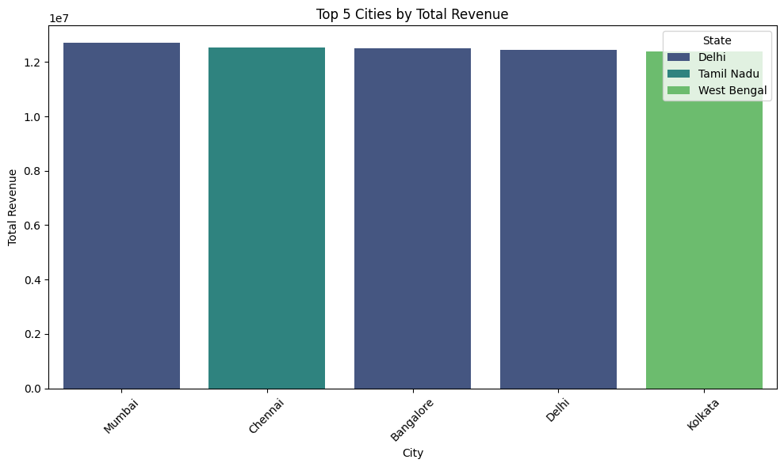

```python
import seaborn as sns
import matplotlib.pyplot as plt

# Plot Top 5
plt.figure(figsize=(10,6))
sns.barplot(data=top_5_cities, x='City', y='Total_Revenue', hue='State', palette='viridis')
plt.title('Top 5 Cities by Total Revenue')
plt.ylabel('Total Revenue')
plt.xticks(rotation=45)
plt.tight_layout()
plt.show()
```

```python
# Define urban cities (expand as needed)
urban_cities = ['Mumbai', 'Delhi', 'Bangalore', 'Chennai', 'Kolkata', 'Hyderabad', 'Ahmedabad', 'Pune']

# Create Urban/Rural classification
df['Area_Type'] = df['City'].apply(lambda x: 'Urban' if x in urban_cities else 'Rural')

# Group by Area Type
area_sales = df.groupby('Area_Type').agg(
    Total_Orders=('Order ID', 'nunique'),
    Total_Revenue=('Total Sales', 'sum')
).reset_index()
```

```python
# Count purchases per customer
customer_purchase_counts = df.groupby('Customer ID').size().reset_index(name='Purchase_Count')

# Merge back to get state info
customer_purchase_info = customer_purchase_counts.merge(customer_location_df, on='Customer ID')

# Define repeat customers as those with more than 1 purchase
customer_purchase_info['Is_Repeat'] = customer_purchase_info['Purchase_Count'] > 1

# State-wise repeat customer rate
repeat_by_state = customer_purchase_info.groupby('State')['Is_Repeat'].mean().reset_index()
repeat_by_state.rename(columns={'Is_Repeat': 'Repeat_Purchase_Rate'}, inplace=True)
```

```python
category_state_sales = df.groupby(['State', 'Category']).agg(
    Total_Revenue=('Total Sales', 'sum'),
    Total_Orders=('Order ID', 'nunique')
).reset_index()

# Optional: Rank categories within each state
category_state_sales['Category_Rank'] = category_state_sales.groupby('State')['Total_Revenue'].rank(ascending=False)
```

```python
top_categories_per_state = category_state_sales[category_state_sales['Category_Rank'] == 1]
```

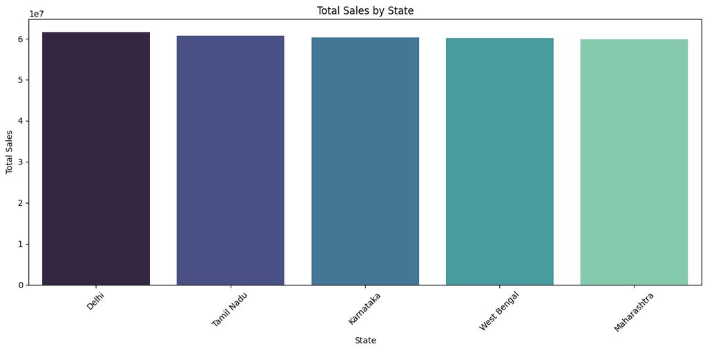

```python
#Visualize the Data on a Heatmap
import seaborn as sns
import matplotlib.pyplot as plt

# Aggregate sales by state
state_sales = df.groupby('State')['Total Sales'].sum().sort_values(ascending=False).reset_index()

# Bar plot
plt.figure(figsize=(12,6))
sns.barplot(data=state_sales, x='State', y='Total Sales', palette='mako')
plt.xticks(rotation=45)
plt.title('Total Sales by State')
plt.tight_layout()
plt.show()
```

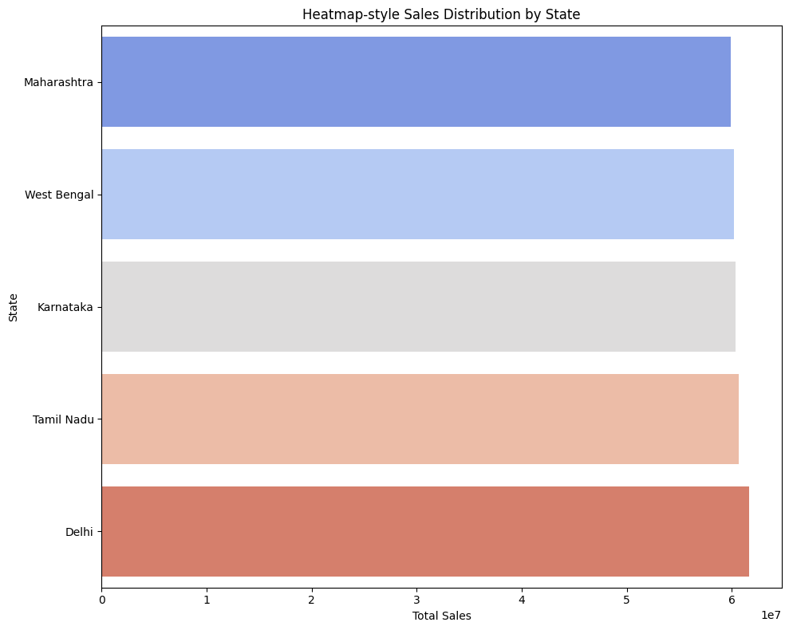

```python
import seaborn as sns
import matplotlib.pyplot as plt

# Sort by sales
state_sales_sorted = state_sales.sort_values(by='Total Sales', ascending=True)

# Heatmap-style bar chart
plt.figure(figsize=(10, 8))
sns.barplot(
    data=state_sales_sorted,
    x='Total Sales',
    y='State',
    palette='coolwarm'
)
plt.title('Heatmap-style Sales Distribution by State')
plt.xlabel('Total Sales')
plt.ylabel('State')
plt.tight_layout()
plt.show()
```

```python
import plotly.express as px

fig = px.treemap(
    state_sales,
    path=['State'],
    values='Total Sales',
    color='Total Sales',
    color_continuous_scale='YlGnBu',
    title='Sales Contribution by State'
)
fig.show()
```

[interactive chart not shown]

```python
# Approximate population in millions (replace or update as needed)
state_population = {
    'Maharashtra': 124.8,
    'Uttar Pradesh': 231.5,
    'Bihar': 128.0,
    'West Bengal': 100.0,
    'Madhya Pradesh': 85.0,
    'Tamil Nadu': 78.8,
    'Rajasthan': 81.0,
    'Karnataka': 70.0,
    'Gujarat': 71.5,
    'Andhra Pradesh': 53.5,
    'Delhi': 32.0,
    'Punjab': 30.0,
    'Kerala': 35.0,
    'Haryana': 29.0,
    'Telangana': 39.0,
    'Odisha': 46.0,
    'Chhattisgarh': 32.0,
    'Assam': 35.5,
    'Jharkhand': 39.0
    # Add others as needed
}

# Map population to state_sales DataFrame
state_sales['Population (Millions)'] = state_sales['State'].map(state_population)
```

```python
state_sales['Sales per Capita (INR)'] = state_sales['Total Sales'] / (state_sales['Population (Millions)'] * 1_000_000)
```

```python
# Thresholds (tune these as needed)
low_penetration = state_sales[state_sales['Sales per Capita (INR)'] < state_sales['Sales per Capita (INR)'].quantile(0.25)]
high_population = low_penetration[low_penetration['Population (Millions)'] > state_sales['Population (Millions)'].median()]

# These states may have market potential
high_potential_states = high_population.sort_values(by='Sales per Capita (INR)')
```

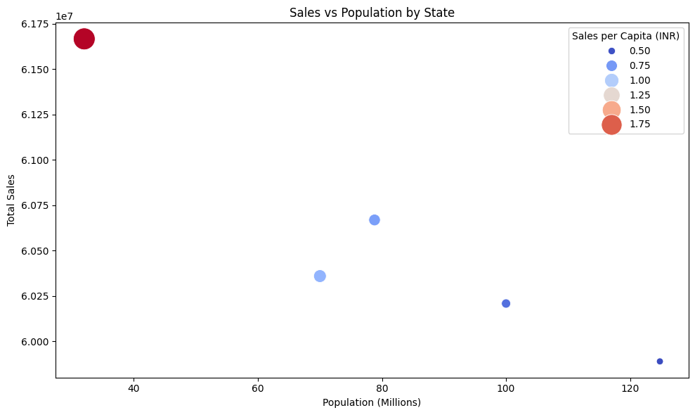

```python
plt.figure(figsize=(10,6))
sns.scatterplot(data=state_sales, x='Population (Millions)', y='Total Sales',
                size='Sales per Capita (INR)', hue='Sales per Capita (INR)',
                palette='coolwarm', sizes=(50, 500), legend='brief')
plt.title('Sales vs Population by State')
plt.xlabel('Population (Millions)')
plt.ylabel('Total Sales')
plt.tight_layout()
plt.show()
```

This bubble chart highlights:

Large population, low sales per capita = underpenetrated

Small population, high sales per capita = saturated or loyal market

```python
print(df.describe())
```

```
               Price       Quantity    Total Sales  Customer Age
count  100000.000000  100000.000000  100000.000000  100000.00000
mean      550.550363       5.493160    3027.926702      44.01757
std       260.558267       2.882013    2274.140853      15.30850
min       100.050000       1.000000     100.050000      18.00000
25%       323.967500       3.000000    1153.515000      31.00000
50%       551.100000       5.000000    2433.885000      44.00000
75%       777.125000       8.000000    4443.337500      57.00000
max       999.990000      10.000000    9999.400000      70.00000
```

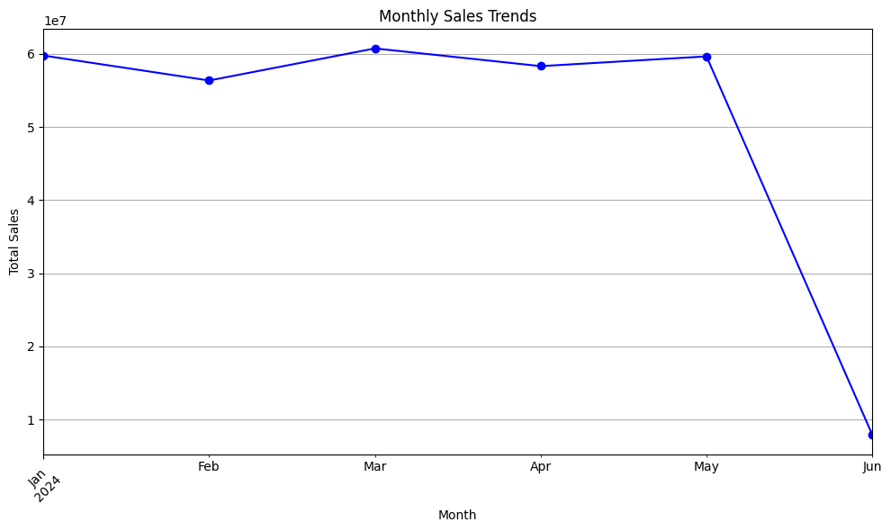

```python
import matplotlib.pyplot as plt
import pandas as pd

# Assuming you have a DataFrame 'df' with 'Purchase Date' and 'Total Sales' columns
df['Purchase Date'] = pd.to_datetime(df['Purchase Date'])
df['Month'] = df['Purchase Date'].dt.to_period('M')

monthly_sales = df.groupby('Month')['Total Sales'].sum()

plt.figure(figsize=(10, 6))
monthly_sales.plot(kind='line', marker='o', color='b')
plt.title('Monthly Sales Trends')
plt.xlabel('Month')
plt.ylabel('Total Sales')
plt.grid(True)
plt.xticks(rotation=45)
plt.tight_layout()
plt.show()
```

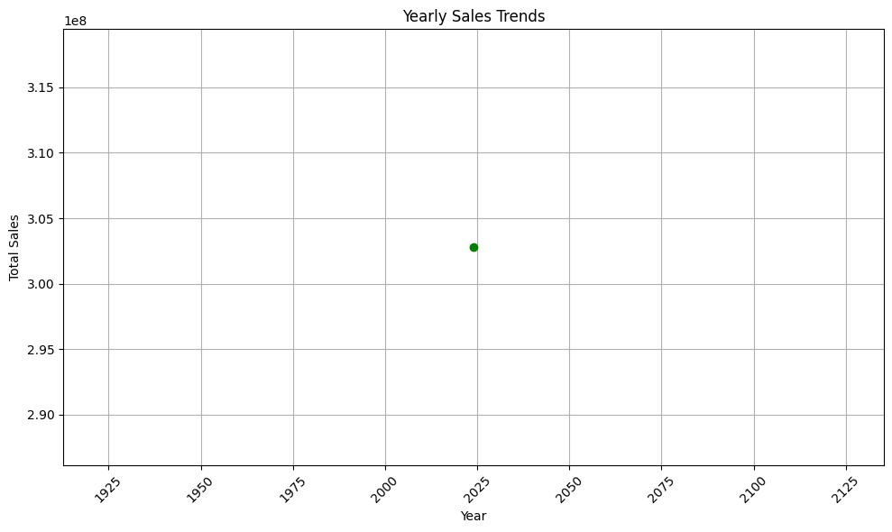

```python
df['Year'] = df['Purchase Date'].dt.year
yearly_sales = df.groupby('Year')['Total Sales'].sum()

plt.figure(figsize=(10, 6))
yearly_sales.plot(kind='line', marker='o', color='g')
plt.title('Yearly Sales Trends')
plt.xlabel('Year')
plt.ylabel('Total Sales')
plt.grid(True)
plt.xticks(rotation=45)
plt.tight_layout()
plt.show()
```

2️⃣ Best-Selling Products & Categories Bar Chart for Best-Selling Products: This chart will highlight the products with the highest sales.

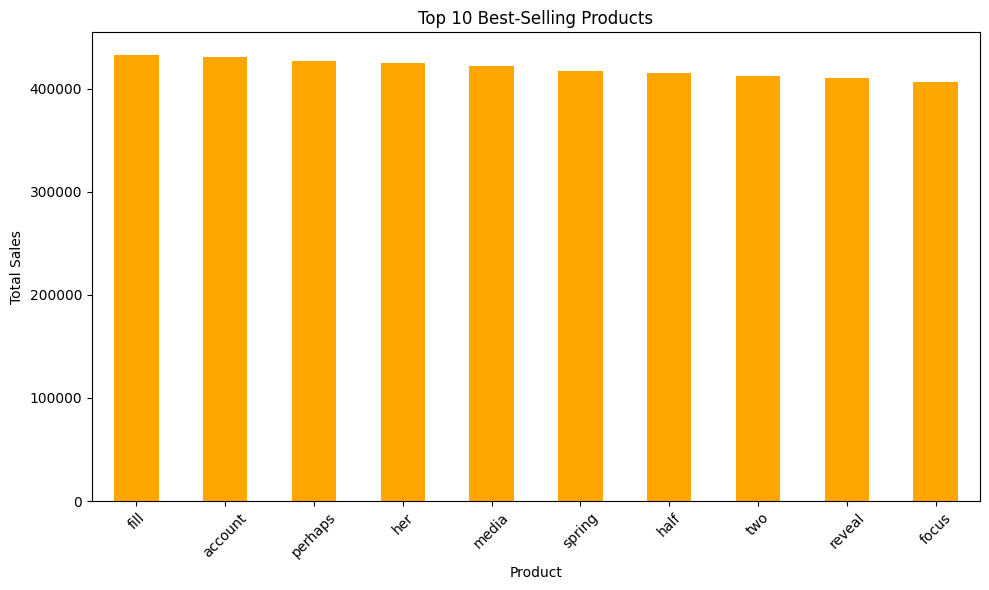

```python
product_sales = df.groupby('Product Name')['Total Sales'].sum().sort_values(ascending=False).head(10)

plt.figure(figsize=(10, 6))
product_sales.plot(kind='bar', color='orange')
plt.title('Top 10 Best-Selling Products')
plt.xlabel('Product')
plt.ylabel('Total Sales')
plt.xticks(rotation=45)
plt.tight_layout()
plt.show()
```

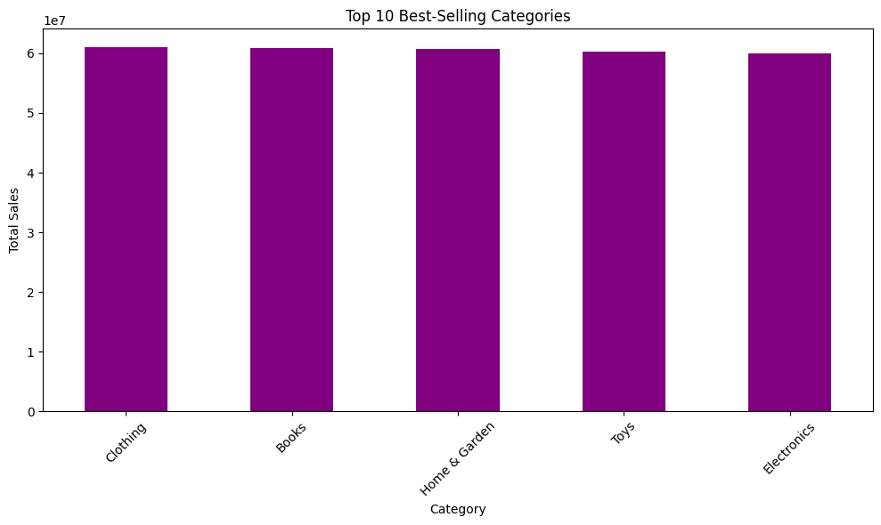

```python
category_sales = df.groupby('Category')['Total Sales'].sum().sort_values(ascending=False).head(10)

plt.figure(figsize=(10, 6))
category_sales.plot(kind='bar', color='purple')
plt.title('Top 10 Best-Selling Categories')
plt.xlabel('Category')
plt.ylabel('Total Sales')
plt.xticks(rotation=45)
plt.tight_layout()
plt.show()
```

3️⃣ Heatmap/Geographical Visualization of Sales by Location For this part, if you have location data available (e.g., city, state), a heatmap can be generated to visualize the sales distribution across different geographic areas. We can also use choropleth maps for a more advanced geographical analysis.

Heatmap of Sales by Location (States): If you have sales data broken down by state, here’s how you could create a heatmap using seaborn.

```python
# Assuming you have a 'State' column in your dataset and a 'Total Sales' column
state_sales_df = df.groupby('State')['Total Sales'].sum().reset_index()

# Check if 'state_sales_df' is correctly created
print(state_sales_df.head())
```

```
         State  Total Sales
0        Delhi  61665856.39
1    Karnataka  60359637.39
2  Maharashtra  59889851.82
3   Tamil Nadu  60668703.19
4  West Bengal  60208621.39
```

```python
import plotly.express as px

# Assuming 'state_sales_df' contains the summed total sales per state
fig = px.choropleth(state_sales_df,
                    locations='State',
                    locationmode='country names',  # Modify for the correct geojson structure
                    color='Total Sales',
                    color_continuous_scale='Viridis',
                    title='Sales by State')

# Set geographic boundaries for the map
fig.update_geos(fitbounds="locations", visible=False)

# Show the map
fig.show()
```

[interactive chart not shown]

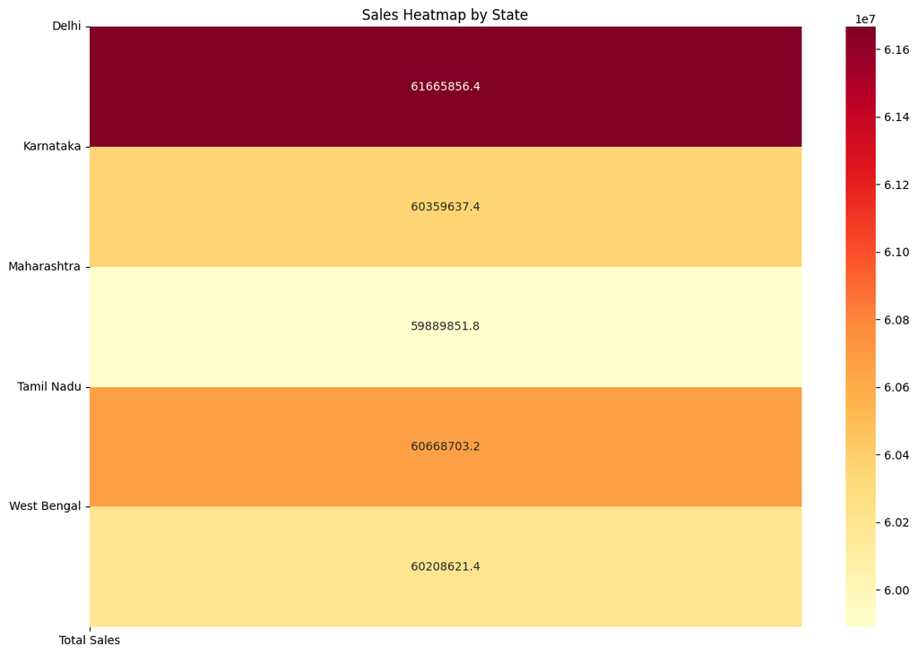

```python
import seaborn as sns
import matplotlib.pyplot as plt

# Create a heatmap for sales by state
plt.figure(figsize=(12, 8))
sns.heatmap(state_sales_df.set_index('State')['Total Sales'].values.reshape(-1, 1),
            annot=True, fmt='.1f', cmap='YlOrRd', cbar=True)

# Add titles and labels
plt.title('Sales Heatmap by State')
plt.xticks([0], ['Total Sales'])
plt.yticks(range(len(state_sales_df)), state_sales_df['State'], rotation=0)

# Adjust layout
plt.tight_layout()
plt.show()
```

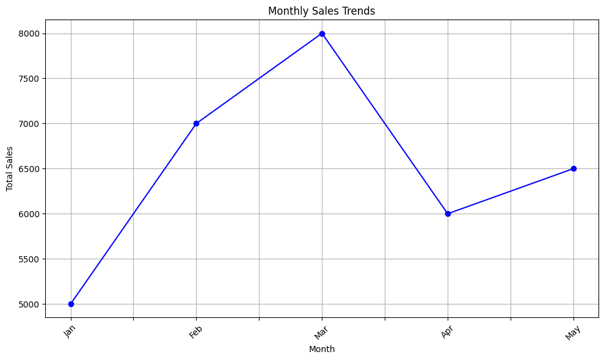

```python
import matplotlib.pyplot as plt
import pandas as pd

# Example data (assuming monthly_sales data is available)
monthly_sales = pd.Series([5000, 7000, 8000, 6000, 6500], index=['Jan', 'Feb', 'Mar', 'Apr', 'May'])

# Create the line plot
plt.figure(figsize=(10, 6))
monthly_sales.plot(kind='line', marker='o', color='b')
plt.title('Monthly Sales Trends')
plt.xlabel('Month')
plt.ylabel('Total Sales')
plt.grid(True)
plt.xticks(rotation=45)
plt.tight_layout()

# Save the plot as an image
plt.savefig('monthly_sales_trends.png')  # Save as PNG file

# Optionally, show the plot
plt.show()
```

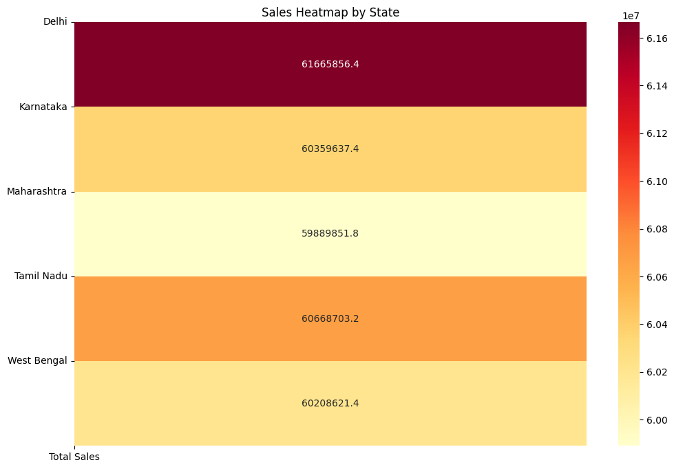

```python
import seaborn as sns

# Example data for the heatmap
state_sales = pd.Series([61665856.39, 60359637.39, 59889851.82, 60668703.19, 60208621.39],
                       index=['Delhi', 'Karnataka', 'Maharashtra', 'Tamil Nadu', 'West Bengal'])

# Create the heatmap
plt.figure(figsize=(12, 8))
sns.heatmap(state_sales.values.reshape(-1, 1), annot=True, fmt='.1f', cmap='YlOrRd', cbar=True)

# Add titles and labels
plt.title('Sales Heatmap by State')
plt.xticks([0], ['Total Sales'])
plt.yticks(range(len(state_sales)), state_sales.index, rotation=0)

# Save the heatmap as an image
plt.savefig('sales_heatmap_by_state.png')  # Save as PNG file

# Optionally, show the plot
plt.show()
```

```python
import plotly.express as px
import pandas as pd

# Example data for the bar chart
state_sales_df = pd.DataFrame({
    'State': ['Delhi', 'Karnataka', 'Maharashtra', 'Tamil Nadu', 'West Bengal'],
    'Total Sales': [61665856.39, 60359637.39, 59889851.82, 60668703.19, 60208621.39]
})

# Create the bar chart
fig = px.bar(state_sales_df, x='State', y='Total Sales', title='Sales by State')

# Save the Plotly chart as an interactive HTML file
fig.write_html("sales_by_state_plotly.html")  # Save as HTML file
```

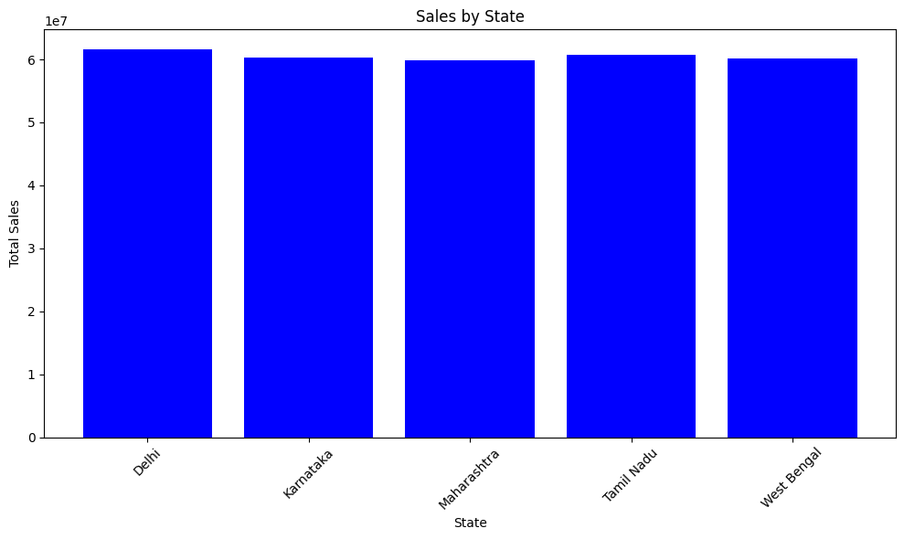

```python
import matplotlib.pyplot as plt
import pandas as pd

# Example data for the bar chart
state_sales_df = pd.DataFrame({
    'State': ['Delhi', 'Karnataka', 'Maharashtra', 'Tamil Nadu', 'West Bengal'],
    'Total Sales': [61665856.39, 60359637.39, 59889851.82, 60668703.19, 60208621.39]
})

# Create the bar chart using Matplotlib
plt.figure(figsize=(10, 6))
plt.bar(state_sales_df['State'], state_sales_df['Total Sales'], color='b')
plt.title('Sales by State')
plt.xlabel('State')
plt.ylabel('Total Sales')
plt.xticks(rotation=45)
plt.tight_layout()

# Save the bar chart as an image (PNG file)
plt.savefig('sales_by_state_matplotlib.png')  # Save as PNG file

# Optionally, show the plot
plt.show()
```

Summary: If you prefer interactive charts, use Plotly's write_html() method.

If you want a static chart, use Matplotlib or Seaborn, which can be saved easily as images with the savefig() method.

3️⃣ Updated Dataset (CSV File)

```python
import pandas as pd

# Sample dataset (you can load your actual data here)
data = {
    'Order ID': [1, 2, 3, 4, 5],
    'Product Name': ['A', 'B', 'C', 'A', 'B'],
    'Category': ['Electronics', 'Clothing', 'Electronics', 'Electronics', 'Clothing'],
    'Price': [1000, 500, 1500, 1200, 600],
    'Quantity': [1, 2, 1, 2, 3],
    'Total Sales': [1000, 1000, 1500, 2400, 1800],
    'Customer ID': ['C001', 'C002', 'C003', 'C004', 'C005'],
    'Customer Age': [30, 25, 35, 40, 22],
    'Customer Gender': ['M', 'F', 'M', 'M', 'F'],
    'Purchase Date': ['2025-01-01', '2025-01-15', '2025-02-01', '2025-02-10', '2025-03-01'],
    'Purchase Time': ['10:00', '14:00', '11:00', '15:00', '13:00'],
    'Location': ['Delhi', 'Mumbai', 'Bangalore', 'Delhi', 'Mumbai']
}

df = pd.DataFrame(data)

# Convert 'Purchase Date' to datetime
df['Purchase Date'] = pd.to_datetime(df['Purchase Date'])

# 1️⃣ Add Monthly Sales
df['Year'] = df['Purchase Date'].dt.year
df['Month'] = df['Purchase Date'].dt.month

# Calculate total sales by Month
monthly_sales = df.groupby(['Year', 'Month'])['Total Sales'].sum().reset_index()

# 2️⃣ Revenue by Region (Location)
revenue_by_region = df.groupby('Location')['Total Sales'].sum().reset_index()

# 3️⃣ Product Category Trends
category_trends = df.groupby(['Year', 'Category'])['Total Sales'].sum().reset_index()

# Merge these results with the original dataset or save them separately for later use

# 4️⃣ Combine everything into a final dataset (optional)
df_final = df.copy()

# Save the updated dataset as a CSV file
df_final.to_csv('updated_sales_data.csv', index=False)

# You can also save the aggregated data separately for insights:
monthly_sales.to_csv('monthly_sales.csv', index=False)
revenue_by_region.to_csv('revenue_by_region.csv', index=False)
category_trends.to_csv('category_trends.csv', index=False)

print("Updated dataset saved as 'updated_sales_data.csv'")
```

```
Updated dataset saved as 'updated_sales_data.csv'
```